# Written 2 Game

Matthias Fuchs

7/23/2019

# Overall Effect

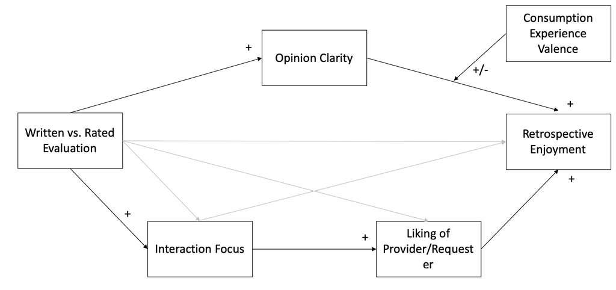

Writing evaluations impacts restrospective evaluations via two paths.

Writing impacts retrospective evalutions via increasing the clarity of one’s own opinion and via increasing the interaction focus. While the indirect effect of opinion clarity is moderated by the valence of the consumption experience, the indirect effect of interaction focus always increases retrospective enjoyment.

# Positive Condition

Prestudy gave this an enjoment rating of 4.78 / 7 (n=15).

[interactive chart not shown]

# Negative Condition

Prestudy gave this an enjoment rating of 1.5 / 7 (n=10).

[interactive chart not shown]

# Looking at overall summary statistics

## Retrospective Enjoyment

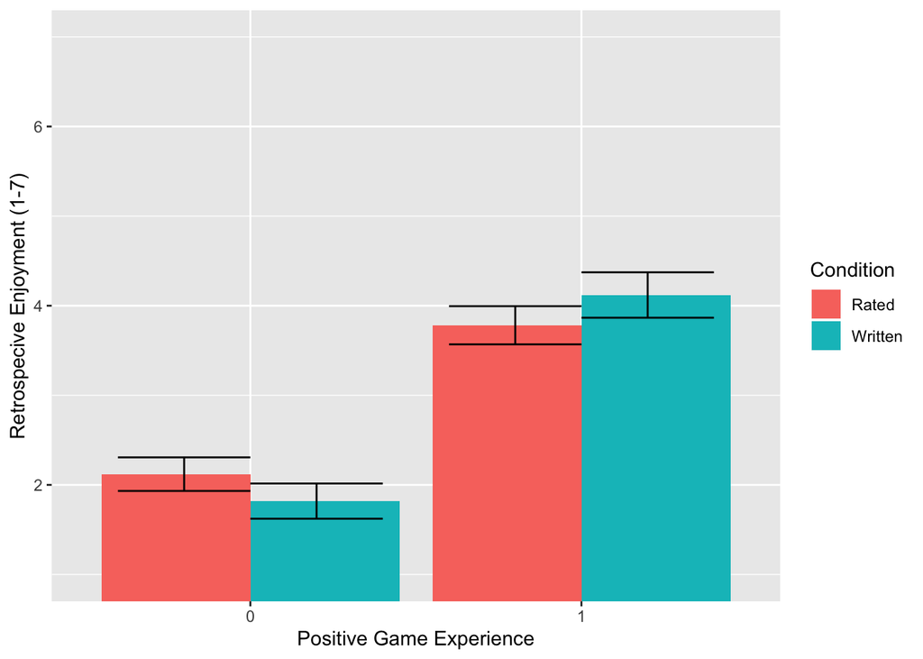

|  | *Dependent variable:* |  |
| --- | --- | --- |
|  | enjoyment |  |
|  | (1) | (2) |
| written | -0.078 | -0.014 |
|  | (0.147) | (0.229) |
| gamegood | 0.661*** | 0.700*** |
|  | (0.160) | (0.192) |
| crm | 1.271*** | 1.276*** |
|  | (0.185) | (0.185) |
| I(crm2) | -0.063*** | -0.063*** |
|  | (0.024) | (0.024) |
| written:gamegood |  | -0.110 |
|  |  | (0.302) |
| Constant | -0.075 | -0.104 |
|  | (0.256) | (0.269) |
| Observations | 263 | 263 |
| R<sup>2</sup> | 0.677 | 0.677 |
| Adjusted R<sup>2</sup> | 0.672 | 0.671 |
| Residual Std. Error | 1.162 (df = 258) | 1.164 (df = 257) |
| F Statistic | 135.086*** (df = 4; 258) | 107.732*** (df = 5; 257) |
| *Note:* | p<0.1; p<0.05; p<0.01 |  |

## Understanding

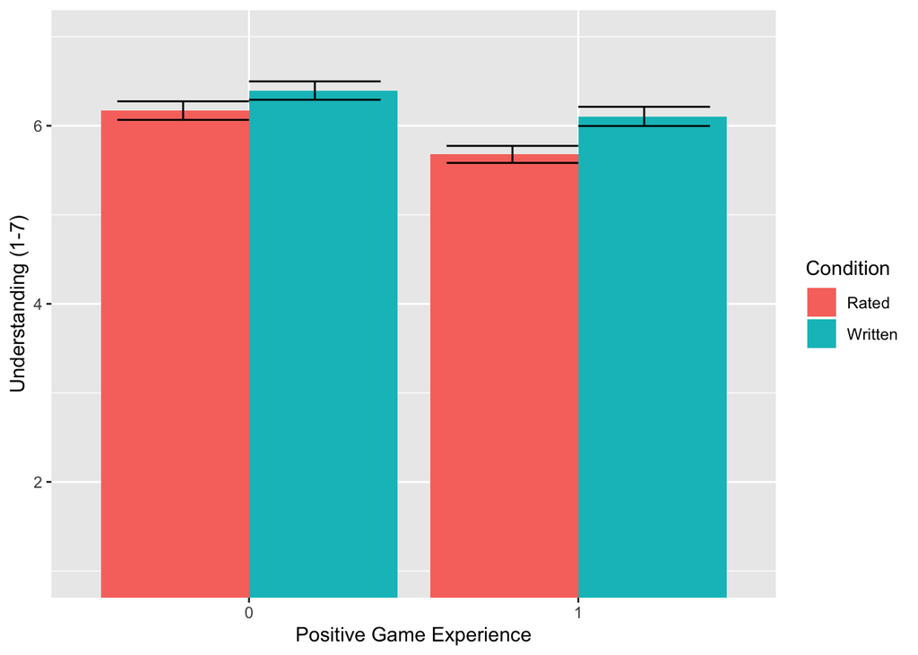

|  | *Dependent variable:* |
| --- | --- |
|  | understanding |
| written | 0.381*** |
|  | (0.103) |
| gamegood | -0.158 |
|  | (0.111) |
| crm | -0.514*** |
|  | (0.128) |
| I(crm2) | 0.051*** |
|  | (0.017) |
| Constant | 6.828*** |
|  | (0.178) |
| Observations | 263 |
| R<sup>2</sup> | 0.180 |
| Adjusted R<sup>2</sup> | 0.167 |
| Residual Std. Error | 0.808 (df = 258) |
| F Statistic | 14.126*** (df = 4; 258) |
| *Note:* | p<0.1; p<0.05; p<0.01 |

## Liking of Provider

In spite of the apparent relationship, writing does not significantly influence Liking.

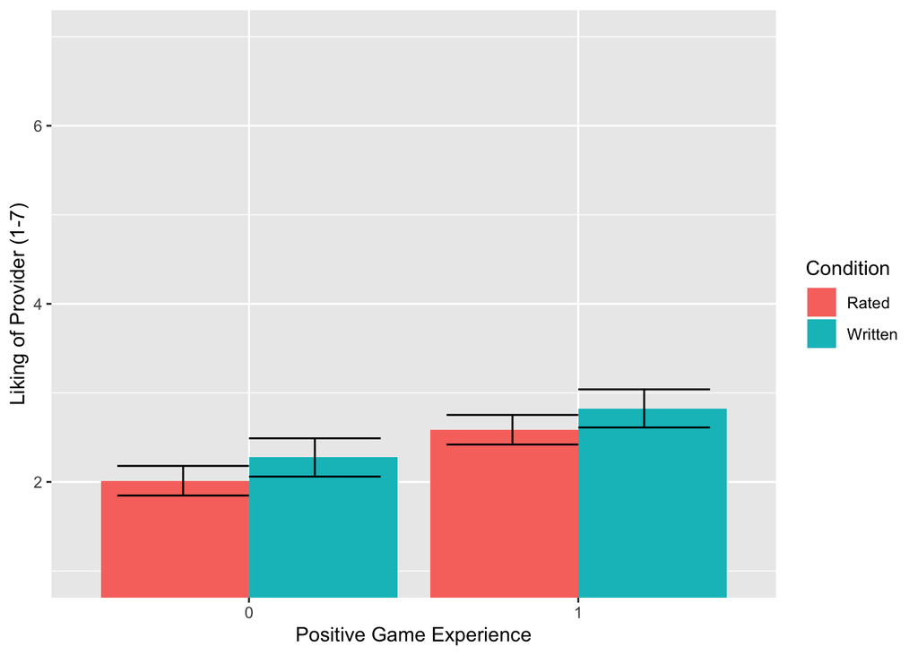

|  | *Dependent variable:* |  |
| --- | --- | --- |
|  | like |  |
|  | (1) | (2) |
| written | 0.190 | 0.401 |
|  | (0.175) | (0.272) |
| gamegood | 0.022 | 0.149 |
|  | (0.190) | (0.228) |
| crm | 0.273 | 0.289 |
|  | (0.219) | (0.220) |
| I(crm2) | 0.015 | 0.014 |
|  | (0.029) | (0.029) |
| written:gamegood |  | -0.363 |
|  |  | (0.358) |
| Constant | 1.424*** | 1.326*** |
|  | (0.304) | (0.319) |
| Observations | 263 | 263 |
| R<sup>2</sup> | 0.219 | 0.222 |
| Adjusted R<sup>2</sup> | 0.207 | 0.207 |
| Residual Std. Error | 1.379 (df = 258) | 1.379 (df = 257) |
| F Statistic | 18.113*** (df = 4; 258) | 14.698*** (df = 5; 257) |
| *Note:* | p<0.1; p<0.05; p<0.01 |  |

## Purchase Intent

The apparent Interaction is not significant.

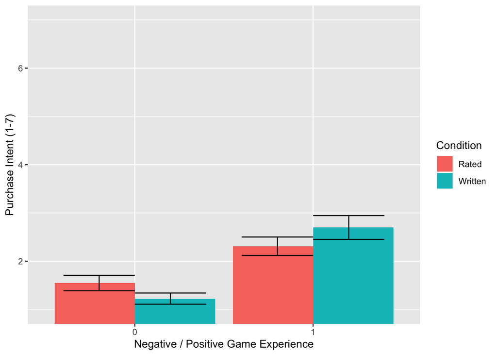

|  | *Dependent variable:* |
| --- | --- |
|  | pi |
| written | -0.116 |
|  | (0.250) |
| gamegood | 0.153 |
|  | (0.209) |
| crm | 0.298 |
|  | (0.202) |
| I(crm2) | 0.038 |
|  | (0.026) |
| written:gamegood | 0.216 |
|  | (0.328) |
| Constant | 0.685** |
|  | (0.293) |
| Observations | 263 |
| R<sup>2</sup> | 0.445 |
| Adjusted R<sup>2</sup> | 0.434 |
| Residual Std. Error | 1.267 (df = 257) |
| F Statistic | 41.210*** (df = 5; 257) |
| *Note:* | p<0.1; p<0.05; p<0.01 |

## Interaction Focus

The difference is significant.

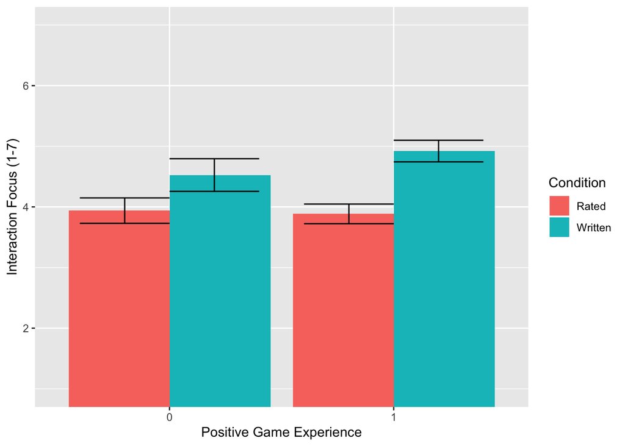

|  | *Dependent variable:* |
| --- | --- |
|  | intfocus |
| written | 0.822*** |
|  | (0.200) |
| gamegood | -0.137 |
|  | (0.218) |
| crm | 0.146 |
|  | (0.251) |
| I(crm2) | 0.004 |
|  | (0.033) |
| Constant | 3.547*** |
|  | (0.348) |
| Observations | 263 |
| R<sup>2</sup> | 0.099 |
| Adjusted R<sup>2</sup> | 0.085 |
| Residual Std. Error | 1.579 (df = 258) |
| F Statistic | 7.118*** (df = 4; 258) |
| *Note:* | p<0.1; p<0.05; p<0.01 |

# The ‘negative’ effect of writing on retrospective enjoyment (‘the understanding / opinion clarity path’)

[figure not shown]

The effect of writing on retrospective enjoyment conditionally mediated by Understanding and Valence.

```
## [1] "Model Parameters:"
##          [,1]
## Model =  "14"
## Y     =  "enjoyment"
## X     =  "written"
## M     =  "understanding2"
## V     =  "gamegood"
## [1] "\nStatistical controls:"
##      [,1]  [,2]
## [1,] "crm" "crmsquare"
## [1] "Sample size:"
## [1] 263
## [1] "*****************************************************************************************"
## [1] "Outcome Variable:  understanding2"
## [1] "Model Summary"
##          R      R-sq        F df1 df2            p
##  0.4002343 0.1601875 16.46739   3 259 7.984534e-10
## [1] "Model"
##                 coeff         se         t            p         LLCI
## Constant   6.89984901 0.18709117 36.879609 0.0000000000  6.531435426
## written    0.32187856 0.10761788  2.990939 0.0030492165  0.109961077
## crm       -0.45023470 0.13000469 -3.463219 0.0006243509 -0.706235528
## crmsquare  0.03732262 0.01734506  2.151773 0.0323398789  0.003167323
##                  ULCI
## Constant   7.26826260
## written    0.53379604
## crm       -0.19423388
## crmsquare  0.07147792
## [1] "*****************************************************************************************"
## [1] "Outcome Variable:  enjoyment"
## [1] "Model Summary"
##                   R      R-sq        F df1 df2 p
## enjoyment 0.8281266 0.6857937 93.12523   6 256 0
## [1] "Model"
##                      coeff         se          t            p        LLCI
## constant        2.40196562 0.96516745  2.4886517 1.345912e-02  0.50128600
## understanding2 -0.36739092 0.13776563 -2.6667821 8.146055e-03 -0.63868926
## written        -0.04316727 0.14849921 -0.2906902 7.715236e-01 -0.33560297
## gamegood       -1.82648863 1.05560584 -1.7302752 8.478624e-02 -3.90526626
## INT_1           0.39680285 0.16696056  2.3766263 1.820764e-02  0.06801169
```

[output cut: 19 more lines]

```
##                gamegood      Effect    Boot SE    BootLLCI    BootULCI
## understanding2        0 -0.11825526 0.05400909 -0.25261361 -0.03245096
## understanding2        1  0.00946707 0.03961749 -0.08344329  0.08781806
##                gamegood      Effect    Boot SE
## understanding2        0 -0.11825526 0.05400909
## understanding2        1  0.00946707 0.03961749
## [1] "****************************** INDEX OF MODERATED MEDIATION ********************************"
##                    Index    Boot SE   BootLLCI  BootULCI
## understanding2 0.1277223 0.06412909 0.03586225 0.3040499
## [1] "When the moderator is dichotomous, this is a test of equality of the indirect effects in the two groups"
## [1] "****************************** ANALYSIS NOTES AND WARNINGS ******************************"
## [1] "Number of bootstrap samples for bias corrected bootstrap confidence intervals:"
## [1] 1000
## [1] "Level of confidence for all confidence intervals in output:"
## [1] 95
```

## The ‘valley of confusion’

Similarly, the same ‘valley of confusion’ is observed. However, this time the increase in understanding caused by writing led to opinions becoming more negative in the negative condition.

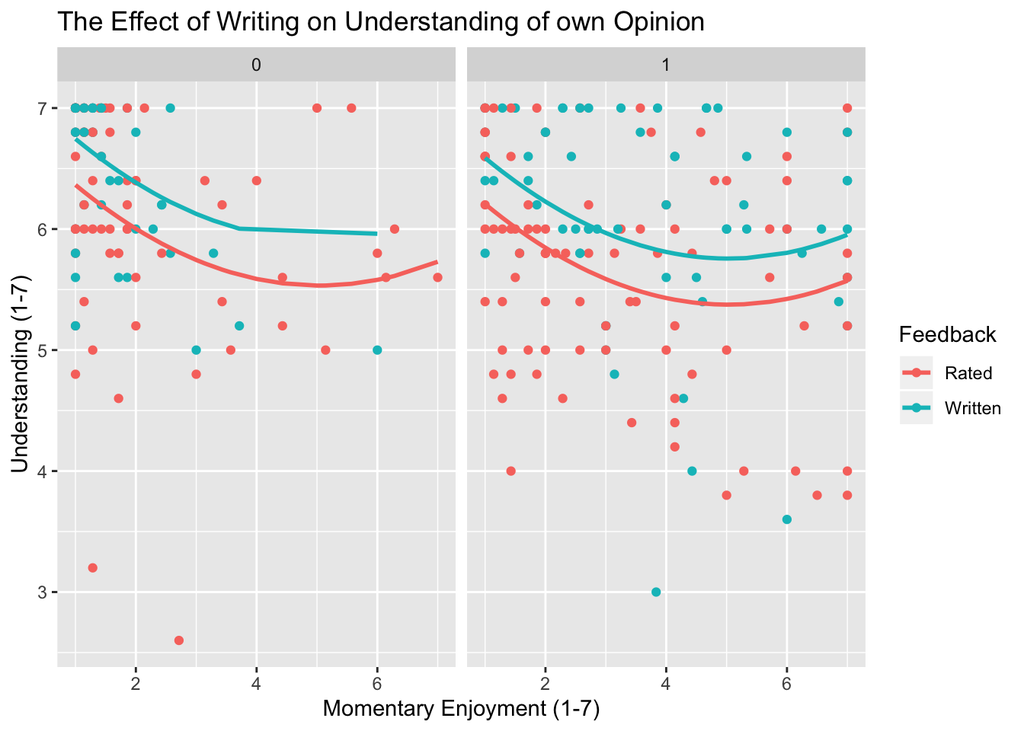

## The interaction of understanding and game valence

This increase in understanding then has a negative effect on th retrospective enjoyment

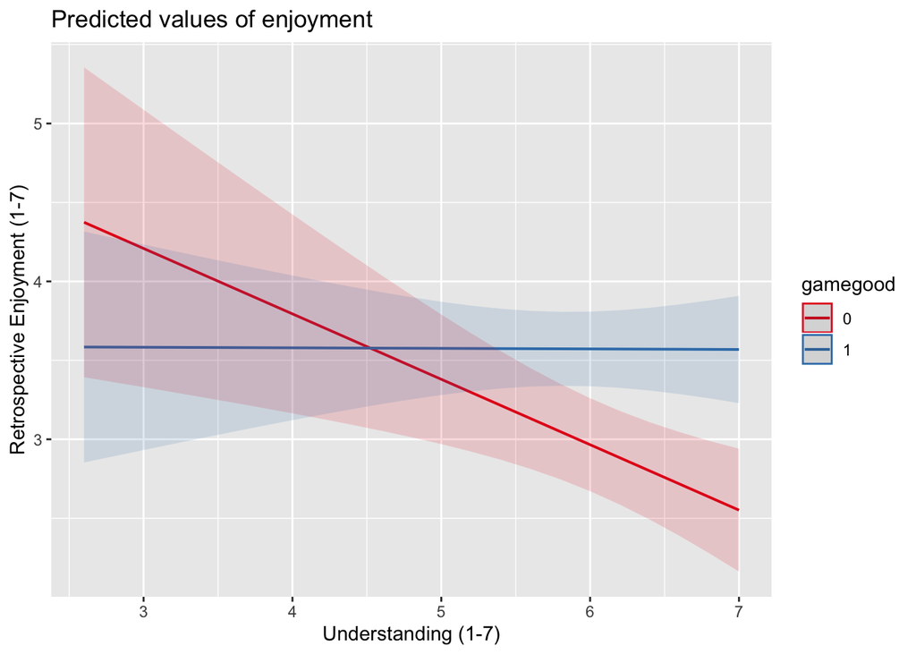

```r
fit_enj=lm(enjoyment~understanding*gamegood+written+crm+I(crm^2),df)
plot_model(fit_enj, type = "int")+labs(x="Understanding (1-7)",y="Retrospective Enjoyment (1-7)")
```

# The positive effect of writing on retrospective enjoyment (‘the interaction focus path’)

Very similar to the effect of loyal consumers who complain like the service more (Umashankar & Dahl). Maybe it is that it isn’t because the consumers are loyal, but because the consumers put more effort into complaining?

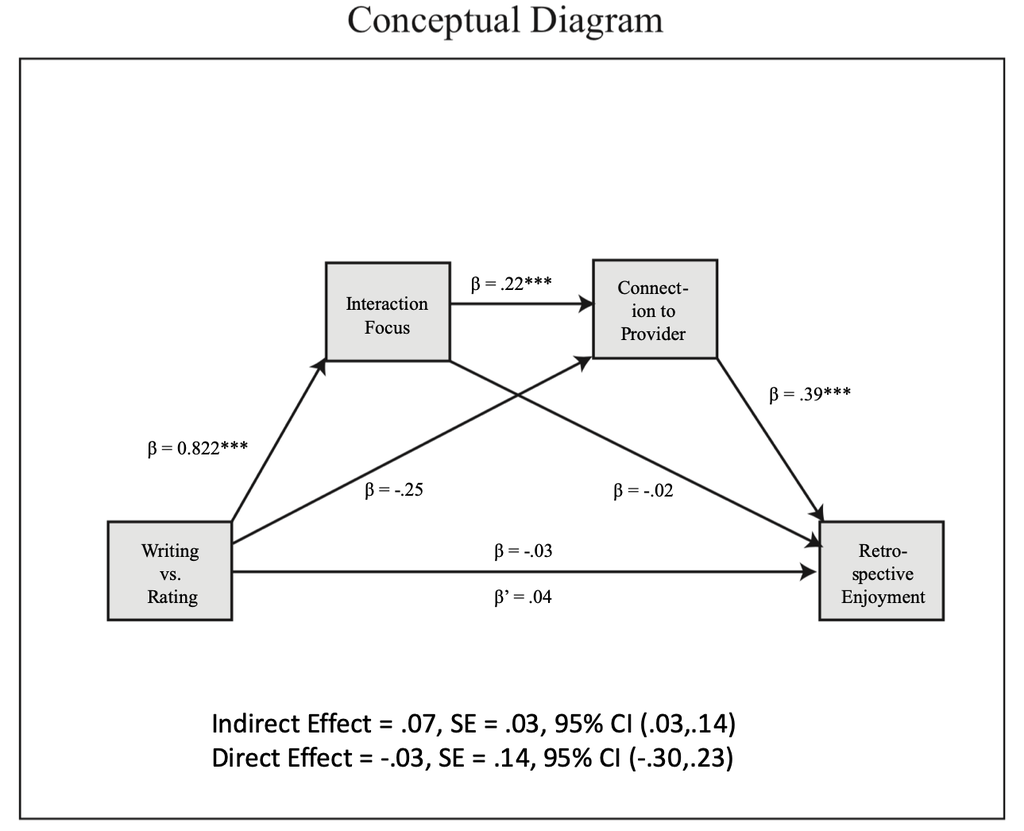

```r
check2 <- process(df, vars=c("written", "intfocus","connect","enjoyment","gamegood","crm", "crmsquare"), model=6, yname="enjoyment", mnames=c("intfocus","connect"), xname="written", total=1, boot=1000)
```

```
## [1] "Model Parameters:"
##          [,1]
## Model =  "6"
## Y     =  "enjoyment"
## X     =  "written"
## M1    =  "intfocus"
## M2    =  "connect"
## [1] "\nStatistical controls:"
##      [,1]       [,2]  [,3]
## [1,] "gamegood" "crm" "crmsquare"
## [1] "Sample size:"
## [1] 263
## [1] "*****************************************************************************************"
## [1] "Outcome Variable:  intfocus"
## [1] "Model Summary"
##         R       R-sq        F df1 df2            p
##  0.315255 0.09938572 7.117785   4 258 1.888169e-05
## [1] "Model"
##                  coeff         se          t            p        LLCI
## Constant   3.547454309 0.34825508 10.1863678 0.000000e+00  2.86166973
## written    0.821739918 0.20042465  4.0999943 5.540285e-05  0.42706331
## gamegood  -0.136560596 0.21785660 -0.6268371 5.313203e-01 -0.56556424
## crm        0.145918540 0.25099049  0.5813708 5.614981e-01 -0.34833242
## crmsquare  0.004377981 0.03283453  0.1333346 8.940327e-01 -0.06027985
##                 ULCI
## Constant  4.23323889
## written   1.21641653
## gamegood  0.29244305
## crm       0.64016950
## crmsquare 0.06903581
## [1] "*****************************************************************************************"
## [1] "Outcome Variable:  connect"
## [1] "Model Summary"
##          R      R-sq        F df1 df2            p
##  0.5009154 0.2509162 17.21716   5 257 1.088019e-14
## [1] "Model"
##                 coeff         se          t            p         LLCI
## Constant   1.73622985 0.34404019  5.0465903 8.518182e-07  1.058732817
## intfocus   0.22317205 0.05193979  4.2967454 2.460829e-05  0.120890240
## written   -0.25295947 0.17257090 -1.4658293 1.439172e-01 -0.592792644
```

[output cut: 56 more lines]

```
##            Effect    Boot SE    BootLLCI   BootULCI
## Total -0.04660484 0.07738537 -0.20607067 0.09854398
## Ind1: -0.01950548 0.03802812 -0.10158404 0.05384552
## Ind2:  0.07143493 0.02647568  0.02936409 0.13480977
## Ind3: -0.09853428 0.07085963 -0.26280456 0.02114981
## [1] "Indirect effect key"
##              xname                          yname
## [1,] "Ind1:" "written" "->" "intfocus" "->" "enjoyment" " "  " "
## [2,] "Ind2:" "written" "->" "intfocus" "->" "connect"   "->" "enjoyment"
## [3,] "Ind3:" "written" "->" "connect"  "->" "enjoyment" " "  " "
## [1] "****************************** ANALYSIS NOTES AND WARNINGS ******************************"
## [1] "Number of bootstrap samples for bias corrected bootstrap confidence intervals:"
## [1] 1000
## [1] "Level of confidence for all confidence intervals in output:"
## [1] 95
```

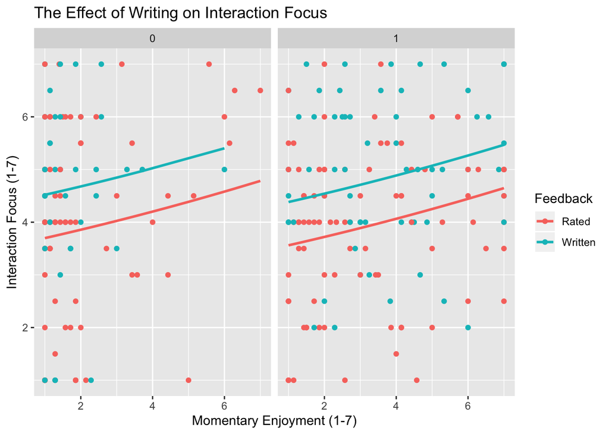

# The Change in Enjoyment does Predict Purchase Intention

```r
fit1=lm(pi~enjoyment+like+written+understanding+crm+I(crm^2),df)

stargazer(fit1,type="html")
```

|  | *Dependent variable:* |
| --- | --- |
|  | pi |
| enjoyment | 0.426*** |
|  | (0.055) |
| like | 0.310*** |
|  | (0.048) |
| written | -0.009 |
|  | (0.135) |
| understanding | -0.023 |
|  | (0.080) |
| crm | -0.351* |
|  | (0.181) |
| I(crm2) | 0.062*** |
|  | (0.022) |
| Constant | 0.372 |
|  | (0.605) |
| Observations | 263 |
| R<sup>2</sup> | 0.632 |
| Adjusted R<sup>2</sup> | 0.623 |
| Residual Std. Error | 1.034 (df = 256) |
| F Statistic | 73.188*** (df = 6; 256) |
| *Note:* | p<0.1; p<0.05; p<0.01 |